# Penentuan Masa Simpan

Direktorat Standardisasi Pangan Olahan

2024-06-04

### Update Responden

Dalam pelaksanaan survei penetuan batas akhir masa simpan, diketahui bahwa dibutuhkan setidaknya 248 responden yang mengisi. Hingga saat ini telah terupdate sebanyak

```r
paste0(total_isi," ","Responden")
```

```
## [1] "275 Responden"
```

dengan persentase *respon rate* sebesar

```r
paste0(respon_rate,"%")
```

```
## [1] "110.89%"
```

Kemudian, akan dilihat *respon rate* berdasarkan Kategori Pangannya

```r
target_kp
```

```
## # A tibble: 16 × 4
##    `Kategori Pangan` `Target Sampel`     N Persen
##    <chr>                       <dbl> <int>  <dbl>
##  1 01                             19    45  237.
##  2 02                             18    28  156.
##  3 03                              5     2   40
##  4 04                             19     9   47.4
##  5 05                             19    23  121.
##  6 06                             19    13   68.4
##  7 07                             19    23  121.
##  8 08                             19     8   42.1
##  9 09                             18     8   44.4
## 10 10                              1     0    0
## 11 11                             11     3   27.3
## 12 12                             19    41  216.
## 13 13                             14     9   64.3
## 14 14                             19    40  211.
## 15 15                             18    16   88.9
## 16 16                             11     7   63.6
```

### Perusahaan yang Sudah Mengisi

```r
reactable(df_summ_company, wrap = FALSE, bordered = TRUE, filterable = TRUE,
          columns = list(
            "Nama Perusahaan" = colDef(
              sticky = "left",
              width = 350)))
```

| Nama Perusahaan | 01 | 02 | 03 | 04 | 05 | 06 | 07 | 08 | 09 | 10 | 11 | 12 | 13 | 14 | 15 | 16 | Jumlah |
| --- | --- | --- | --- | --- | --- | --- | --- | --- | --- | --- | --- | --- | --- | --- | --- | --- | --- |
| ;;jn | 1 | 0 | 0 | 0 | 0 | 0 | 0 | 0 | 0 | 0 | 0 | 0 | 0 | 0 | 0 | 0 | 1 |
| aa | 1 | 0 | 0 | 0 | 0 | 0 | 0 | 0 | 0 | 0 | 0 | 0 | 0 | 0 | 0 | 0 | 1 |
| anj boga | 0 | 0 | 0 | 1 | 0 | 0 | 0 | 0 | 0 | 0 | 0 | 0 | 0 | 0 | 0 | 0 | 1 |
| arnotts indonesia | 0 | 0 | 0 | 0 | 0 | 0 | 1 | 0 | 0 | 0 | 0 | 0 | 0 | 0 | 0 | 0 | 1 |
| aspra food mandiri | 0 | 0 | 0 | 1 | 0 | 0 | 0 | 0 | 0 | 0 | 0 | 0 | 0 | 0 | 0 | 0 | 1 |
| ayam kriuk padasuka | 0 | 0 | 0 | 0 | 0 | 0 | 0 | 1 | 0 | 0 | 0 | 0 | 0 | 0 | 0 | 0 | 1 |
| bulir tama sejahtera | 2 | 0 | 0 | 0 | 0 | 0 | 0 | 0 | 0 | 0 | 0 | 0 | 0 | 0 | 0 | 0 | 2 |
| bumi alam segar | 0 | 0 | 0 | 0 | 0 | 0 | 0 | 0 | 0 | 0 | 0 | 1 | 0 | 0 | 0 | 0 | 1 |
| cv amanda | 0 | 0 | 0 | 0 | 0 | 0 | 1 | 0 | 0 | 0 | 0 | 0 | 0 | 0 | 0 | 0 | 1 |
| cv kreasi pangan kita | 1 | 0 | 0 | 0 | 0 | 0 | 0 | 0 | 0 | 0 | 0 | 0 | 0 | 0 | 0 | 0 | 1 |

[output cut: 92 more lines]

### Sebaran Lama Kerja Responden

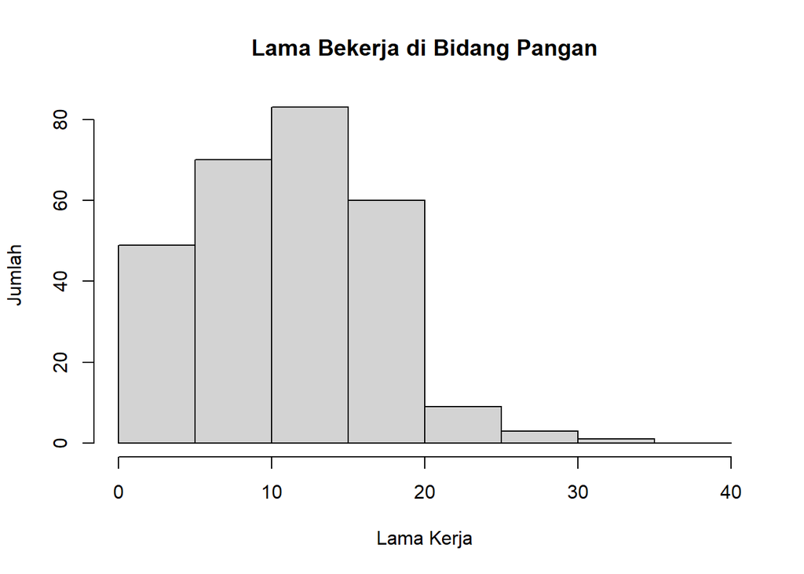

```r
plot(hist_lama_kerja,main = "Lama Bekerja di Bidang Pangan", xlab = "Lama Kerja",ylab = "Jumlah")
```

```r
tbl_lama_kerja
```

```
## # A tibble: 8 × 3
##   `Lama Kerja` Jumlah Persen
##   <chr>         <int>  <dbl>
## 1 0-5              49 17.8
## 2 6-10             70 25.5
## 3 11-15            83 30.2
## 4 16-20            60 21.8
## 5 21-25             9  3.27
## 6 26-30             3  1.09
## 7 31-35             1  0.364
## 8 36-40             0  0
```

### Jenis Pangan per Kategori Pangan

#### Kategori 01.0

```r
tibble(`Jenis Pangan` = tbl_grup_jenis_pangan$`01`)
```

```
## # A tibble: 32 × 1
##    `Jenis Pangan`
##    <chr>
##  1 pangan olahan hasil fermentasi susu
##  2 jenis olahan hasil fermentasi susu yang dipasteurisasi
##  3 es krim
##  4 susu dan krim bubuk
##  5 creamer bubuk 25 kg
##  6 keju cheddar olahan
##  7 minuman susu fermentasi berperisa
##  8 susu uht
##  9 krimer kental manis
## 10 minuman susu kecuali yg disterilisasi
## # ℹ 22 more rows
```

#### Kategori 02.0

```r
tibble(`Jenis Pangan` = tbl_grup_jenis_pangan$`02`)
```

```
## # A tibble: 15 × 1
##    `Jenis Pangan`
##    <chr>
##  1 minyak goreng
##  2 lemak reroti
##  3 margarine
##  4 campuran margarin & mentega
##  5 pengganti minyak mentega
##  6 minyak goreng padat
##  7 02.1.2 margarine
##  8 lemak oles 02.2.2
##  9 minyak goreng sawit
## 10 minyak sawit
## 11 margarin
## 12 butter oil substitute
## 13 non dairy topping, fillings, frosting
## 14 minyak jagung (refined bleached deodorized corn oil)
## 15 minyak kelapa (refined bleached deodorized coconut oil )
```

#### Kategori 03.0

```r
tibble(`Jenis Pangan` = tbl_grup_jenis_pangan$`03`)
```

```
## # A tibble: 1 × 1
##   `Jenis Pangan`
##   <chr>
## 1 water ice
```

#### Kategori 04.0

```r
tibble(`Jenis Pangan` = tbl_grup_jenis_pangan$`04`)
```

```
## # A tibble: 9 × 1
##   `Jenis Pangan`
##   <chr>
## 1 frozen food
## 2 jagung manis
## 3 sayur kering
## 4 agar bubuk
## 5 sayuran beku
## 6 jeli agar
## 7 selai kacang
## 8 jem buah atau selai buah
## 9 santan bubuk
```

#### Kategori 05.0

```r
tibble(`Jenis Pangan` = tbl_grup_jenis_pangan$`05`)
```

```
## # A tibble: 20 × 1
##    `Jenis Pangan`
##    <chr>
##  1 saus/topping/olesan manis
##  2 permen jahe keras dan lunak
##  3 dekorasi, topping, saus manis (05.4)
##  4 pengganti lemak kakao laurat (lauric cocoa butter replacer/ substitute = cbs lauric)
##  5 kembang gula
##  6 cokelat olahan
##  7 kembang gula keras/lunak
##  8 kembang gula karet
##  9 minuman cokelat paduan
## 10 minuman kakao bubuk
## 11 cokelat
## 12 kakao bubuk
## 13 minuman kakao/cokelat
## 14 bubuk minuman cokelat
## 15 bubuk minuman kakao (drinking cocoa mixes)
## 16 cokelat pasta (berbasis minyak)
## 17 minuman serbuk cokelat paduan
## 18 cokelat paduan
## 19 cokelat paduan susu dengan wafer
## 20 cokelat paduan susu
```

#### Kategori 06.0

```r
tibble(`Jenis Pangan` = tbl_grup_jenis_pangan$`06`)
```

```
## # A tibble: 11 × 1
##    `Jenis Pangan`
##    <chr>
##  1 tepung terigu
##  2 lumpia
##  3 makanan ringan
##  4 tepung sagu
##  5 tepung untuk adonan
##  6 tepung bumbu
##  7 sereal sarapan
##  8 sereal sarapan dengan gandum utuh dan biskuit
##  9 pasta instan lainnya
## 10 minuman serealia
## 11 serbuk minuman kedelai
```

#### Kategori 07.0

```r
tibble(`Jenis Pangan` = tbl_grup_jenis_pangan$`07`)
```

```
## # A tibble: 16 × 1
##    `Jenis Pangan`
##    <chr>
##  1 produk bakeri (roti, biskuit, cracker, dan sejenisnya)
##  2 brownies
##  3 produk bakeri
##  4 bakpao
##  5 biskuit
##  6 wafer
##  7 kukis
##  8 roti (bakeri)
##  9 biskuit colek dengan krim (berbagai rasa)
## 10 cake
## 11 pastri
## 12 industri tepung campuran dan adonan tepung
## 13 biscuit
## 14 biskuit, biskuit marie, biskuit marie salut, biskuit sandwich/lapis, wafer, wafer roll, wafer salut, krekers
## 15 bakery premiks (pangan kategori 7 risiko rendah lainnya)
## 16 produk bakeri (roti, biskuit krekers, wafer dan sejenisnya)
```

#### Kategori 08.0

```r
tibble(`Jenis Pangan` = tbl_grup_jenis_pangan$`08`)
```

```
## # A tibble: 8 × 1
##   `Jenis Pangan`
##   <chr>
## 1 olahan daging
## 2 sosis babi
## 3 dimsum frozen
## 4 abon daging
## 5 dimsum
## 6 olahan daging sapi dan unggas
## 7 ayam ungkep goreng dan bakar
## 8 produk olahan daging
```

#### Kategori 09.0

```r
tibble(`Jenis Pangan` = tbl_grup_jenis_pangan$`09`)
```

```
## # A tibble: 6 × 1
##   `Jenis Pangan`
##   <chr>
## 1 terasi udang
## 2 olahan ikan dalam kemasan
## 3 makanan kering
## 4 makanan udang beku
## 5 dimsum
## 6 keripik ikan
```

#### Kategori 10.0

```r
tibble(`Jenis Pangan` = tbl_grup_jenis_pangan$`10`)
```

```
## # A tibble: 0 × 1
## # ℹ 1 variable: Jenis Pangan <chr>
```

#### Kategori 11.0

```r
tibble(`Jenis Pangan` = tbl_grup_jenis_pangan$`11`)
```

```
## # A tibble: 3 × 1
##   `Jenis Pangan`
##   <chr>
## 1 gula
## 2 gula dan pemanis
## 3 gula kristal putih
```

#### Kategori 12.0

```r
tibble(`Jenis Pangan` = tbl_grup_jenis_pangan$`12`)
```

```
## # A tibble: 24 × 1
##    `Jenis Pangan`
##    <chr>
##  1 bumbu dan rempah
##  2 bawang putih bubuk
##  3 kecap manis
##  4 mayonais / salad dressing
##  5 bumbu dan kondimen
##  6 btp msg, bumbu rempah dan kondimen, santan, tepung bumbu
##  7 saus keju
##  8 bumbu siap pakai
##  9 saus bumbu
## 10 saus teremulsi
## # ℹ 14 more rows
```

#### Kategori 13.0

```r
tibble(`Jenis Pangan` = tbl_grup_jenis_pangan$`13`)
```

```
## # A tibble: 7 × 1
##   `Jenis Pangan`
##   <chr>
## 1 formula bayi
## 2 formula lanjutan
## 3 formula pertumbuhan
## 4 pangan keperluan medis khusus
## 5 formula bayi, lanjutan, pertumbuhan
## 6 pkmk
## 7 mpasi
```

#### Kategori 14.0

```r
tibble(`Jenis Pangan` = tbl_grup_jenis_pangan$`14`)
```

```
## # A tibble: 28 × 1
##    `Jenis Pangan`
##    <chr>
##  1 amdk
##  2 amdk air mineral
##  3 minuman teh
##  4 minuman sari kacang hijau
##  5 minuman sari buah asem
##  6 minuman berperisa berkarbonasi
##  7 minuman botanikal berkarbonasi
##  8 minuman buah
##  9 minuman mengandung susu
## 10 air mineral
## # ℹ 18 more rows
```

#### Kategori 15.0

```r
tibble(`Jenis Pangan` = tbl_grup_jenis_pangan$`15`)
```

```
## # A tibble: 12 × 1
##    `Jenis Pangan`
##    <chr>
##  1 malkist
##  2 keripik kentang
##  3 kacang tojin
##  4 makanan ringan
##  5 keripik tempe
##  6 kacang panggang
##  7 makanan ringan ekstrudat
##  8 kacang mede
##  9 makanan ringan siap santap
## 10 makana ringan simulasi
## 11 makanan ringan simulasi
## 12 keripik ubi jalar
```

#### Kategori 16.0

```r
tibble(`Jenis Pangan` = tbl_grup_jenis_pangan$`16`)
```

```
## # A tibble: 7 × 1
##   `Jenis Pangan`
##   <chr>
## 1 kebab beku
## 2 krimer nabati bubuk
## 3 makanan frozen siap saji dalam kemasan
## 4 saus
## 5 mayonais
## 6 pangan siap saji
## 7 olahan sayur dan bumbu frozen
```

### Kemasan Produk

```r
reactable(total_summ_tbl_kemasan, wrap = FALSE, bordered = TRUE, filterable = TRUE,
          columns = list(
            "Kemasan Produk" = colDef(
              sticky = "left",
              width = 350)))
```

| Kemasan Produk | 01 | 02 | 03 | 04 | 05 | 06 | 07 | 08 | 09 | 10 | 11 | 12 | 13 | 14 | 15 | 16 | Jumlah |
| --- | --- | --- | --- | --- | --- | --- | --- | --- | --- | --- | --- | --- | --- | --- | --- | --- | --- |
| Plastik multilapis (multilayer) | 9 | 4 | 0 | 0 | 11 | 6 | 12 | 3 | 3 | 0 | 2 | 19 | 2 | 5 | 5 | 2 | 83 |
| Plastik lapis tunggal (monolayer) | 13 | 7 | 1 | 4 | 2 | 4 | 4 | 3 | 3 | 0 | 1 | 13 | 0 | 16 | 4 | 2 | 77 |
| Logam | 5 | 0 | 0 | 0 | 1 | 0 | 1 | 1 | 1 | 0 | 0 | 6 | 4 | 3 | 0 | 0 | 22 |
| Kertas dan Karton | 4 | 1 | 1 | 0 | 1 | 0 | 1 | 0 | 0 | 0 | 0 | 0 | 1 | 1 | 1 | 0 | 11 |
| Karton Laminat | 4 | 0 | 0 | 0 | 0 | 0 | 0 | 0 | 0 | 0 | 0 | 0 | 0 | 5 | 0 | 0 | 9 |
| Gelas | 0 | 0 | 0 | 2 | 1 | 0 | 0 | 0 | 0 | 0 | 0 | 2 | 0 | 3 | 0 | 0 | 8 |
| Aluminium Foil dalam Dus | 3 | 0 | 0 | 1 | 0 | 1 | 1 | 0 | 0 | 0 | 0 | 0 | 0 | 1 | 0 | 0 | 7 |
| Karton & plastik | 0 | 5 | 0 | 0 | 0 | 0 | 0 | 0 | 0 | 0 | 0 | 0 | 0 | 0 | 0 | 0 | 5 |
| kotak | 0 | 0 | 0 | 0 | 0 | 0 | 1 | 0 | 0 | 0 | 0 | 0 | 0 | 0 | 3 | 0 | 4 |
| n/a | 0 | 4 | 0 | 0 | 0 | 0 | 0 | 0 | 0 | 0 | 0 | 0 | 0 | 0 | 0 | 0 | 4 |

[output cut: 36 more lines]

### Petunjuk Penyimpanan

```r
reactable(total_summ_tbl_penyimpanan, wrap = FALSE, bordered = TRUE, filterable = TRUE,
          columns = list(
            "Petunjuk Penyimpanan 2" = colDef(
              sticky = "left",
              name = "Petunjuk Penyimpanan",
              width = 350)))
```

| Petunjuk Penyimpanan | 01 | 02 | 03 | 04 | 05 | 06 | 07 | 08 | 09 | 10 | 11 | 12 | 13 | 14 | 15 | 16 | Jumlah |
| --- | --- | --- | --- | --- | --- | --- | --- | --- | --- | --- | --- | --- | --- | --- | --- | --- | --- |
| Simpan pada suhu ruang | 31 | 24 | 0 | 5 | 16 | 11 | 17 | 4 | 5 | 0 | 3 | 39 | 9 | 31 | 16 | 3 | 214 |
| Simpan Beku -18 derajat Celcius | 9 | 1 | 2 | 3 | 0 | 1 | 3 | 4 | 3 | 0 | 0 | 0 | 0 | 0 | 0 | 3 | 29 |
| Simpan di tempat sejuk | 0 | 0 | 0 | 0 | 0 | 0 | 0 | 0 | 0 | 0 | 0 | 0 | 0 | 8 | 0 | 0 | 8 |
| Simpan pada suhu dingin 2 - 8 derajat Celcius | 4 | 0 | 0 | 0 | 0 | 0 | 1 | 0 | 0 | 0 | 0 | 0 | 0 | 0 | 0 | 1 | 6 |
| Saran Penyimpanan pada suhu 18 - 25 derajat celcius dan kering | 1 | 0 | 0 | 0 | 1 | 0 | 2 | 0 | 0 | 0 | 0 | 0 | 0 | 0 | 0 | 0 | 4 |
| Simpan di tempat sejuk dan terhindar dari sinar matahari langsung | 0 | 2 | 0 | 0 | 0 | 0 | 0 | 0 | 0 | 0 | 0 | 0 | 0 | 0 | 0 | 0 | 2 |
| NA | 0 | 0 | 0 | 0 | 2 | 0 | 0 | 0 | 0 | 0 | 0 | 0 | 0 | 0 | 0 | 0 | 2 |
| Simpan di tempat bersih dan sejuk. Hindarkan dari sinar matahari langsung dan benda-benda berbau tajam. | 0 | 0 | 0 | 0 | 0 | 0 | 0 | 0 | 0 | 0 | 0 | 0 | 0 | 1 | 0 | 0 | 1 |
| Simpan di tempat sejuk dan kering | 0 | 0 | 0 | 0 | 0 | 1 | 0 | 0 | 0 | 0 | 0 | 0 | 0 | 0 | 0 | 0 | 1 |
| Simpan di tempat sejuk dan kering, simpan di kulkas setelah dibuka | 0 | 0 | 0 | 1 | 0 | 0 | 0 | 0 | 0 | 0 | 0 | 0 | 0 | 0 | 0 | 0 | 1 |

[output cut: 7 more lines]

### Cara Penyiapan

Berikut adalah cara penyiapan produk oleh konsumen pada masing-masing kategori pangan. `$01` adalah menujukkan kategori pangannya yang menandakan Kategori Pangan 01.0

#### Kategori Pangan 01.0

```r
summ_df_cara_penyiapan$`01`
```

```
## # A tibble: 21 × 2
##    `Cara Penyiapan`                                                                                                    Jumlah
##    <chr>                                                                                                                <dbl>
##  1 "siap konsumsi"                                                                                                         14
##  2 "dilarutkan"                                                                                                             6
##  3 "-"                                                                                                                      5
##  4 "\"penyiapan hangat: 1. larutkan 4sdm susu hilo ke dalam 200 ml air hangat 2. aduk rata 3. siap disajikan  penyiap…      2
##  5 "langsung dikonsumsi"                                                                                                    2
##  6 "\"disajikan digin lebih nikmat kocok dahulu sebelum dibuka segera habiskan setelah dibuka\""                            1
##  7 "\"larutkan1 sachet hilo ke dalam 100 ml air dingin. aduk sampai rata \""                                                1
##  8 "\"larutkan1 sachet hilo ke dalam 200 ml air hangat suam-suam kuku (±50°c). jangan menggunakan air mendidih yang d…      1
##  9 "dicampur dengan bahan lainnya kemudian dimasak atau dicampur dengan bahan lainnya untuk dimasukan ke dalam mesin …      1
## 10 "dicampur kembali dengan bahan lain"                                                                                     1
## # ℹ 11 more rows
```

#### Kategori Pangan 02.0

```r
summ_df_cara_penyiapan$`02`
```

```
## # A tibble: 8 × 2
##   `Cara Penyiapan`                                                            Jumlah
##   <chr>                                                                        <dbl>
## 1 dapat langsung digunakan sesuai kebutuhan                                       14
## 2 n/a                                                                              8
## 3 bisa dituangkan langsung ke dalam minuman, dicampur dengan susu dan di whip      1
## 4 cocok digunakan untuk salad dressing, menumis, menggoreng dan memanggang.        1
## 5 cocok untuk salad dressing dan hidangan sehari-hari                              1
## 6 dicampurakan ke dalam adonan                                                     1
## 7 n                                                                                1
## 8 pengolesan loyang                                                                1
```

#### Kategori Pangan 03.0

```r
summ_df_cara_penyiapan$`03`
```

```
## # A tibble: 1 × 2
##   `Cara Penyiapan` Jumlah
##   <chr>             <dbl>
## 1 siap konsumsi         2
```

#### Kategori Pangan 04.0

```r
summ_df_cara_penyiapan$`04`
```

```
## # A tibble: 7 × 2
##   `Cara Penyiapan`                                                                                                     Jumlah
##   <chr>                                                                                                                 <dbl>
## 1 siap konsumsi                                                                                                             3
## 2 1 sachet = 4 sendok teh santan. larutkan 1-4 sendok teh ke dalam 15-60 ml air. jika perlu, tambahkan air sesuai sel…      1
## 3 di kukus                                                                                                                  1
## 4 di steam, atau microwave                                                                                                  1
## 5 dihangatkan dan siap konsumsi                                                                                             1
## 6 ditambahkan air, dimasak hingga mendidih                                                                                  1
## 7 siap konsumsi bersama dengan pangan lain                                                                                  1
```

#### Kategori Pangan 05.0

```r
summ_df_cara_penyiapan$`05`
```

```
## # A tibble: 12 × 2
##    `Cara Penyiapan`                                                                                           Jumlah
##    <chr>                                                                                                       <dbl>
##  1 "siap konsumsi"                                                                                                 8
##  2 "dilarutkan"                                                                                                    4
##  3 "siap dikonsumsi"                                                                                               2
##  4 "\"larutkan1 sachet hilo ke dalam 100 ml air hangat.aduk sampai rata & tambahkan es batu sesuai selera \""      1
##  5 "dioles"                                                                                                        1
##  6 "diseduh menggunakan air panas 150 ml"                                                                          1
##  7 "n/a"                                                                                                           1
##  8 "siap digunakan dengan cara diseduh air panas / air dingin"                                                     1
##  9 "siap digunakan seperti menjadi dekorasi bakery dan isian bakery, dicampur ke dalam adonan"                     1
## 10 "siap digunakan untuk campuran bahan makanan"                                                                   1
## 11 "siap dikonsumsi dengan di cacah atau dimelting sebelum digunakan"                                              1
## 12 "siap makan / ready to eat"                                                                                     1
```

#### Kategori Pangan 06.0

```r
summ_df_cara_penyiapan$`06`
```

```
## # A tibble: 11 × 2
##    `Cara Penyiapan`                                                                                                    Jumlah
##    <chr>                                                                                                                <dbl>
##  1 -                                                                                                                        2
##  2 siap konsumsi                                                                                                            2
##  3 dicampur dengan susu                                                                                                     1
##  4 digunakan untuk melapisi bahan pangan lalu digoreng                                                                      1
##  5 dihangatkan melalui pemasakan (digoreng)                                                                                 1
##  6 diolah atau dimasak menjadi produk siap konsumsi                                                                         1
##  7 direbus                                                                                                                  1
##  8 ditambahkan air kemudian dibalurkan kepada bahan masakan dan digoreng                                                    1
##  9 produk dicampur dengan bahan lain untuk kemudian dapat dipanggang, digoreng dsb sebelum dikonsumsi                       1
## 10 sebagai bahan tambahan                                                                                                   1
## 11 tuangkan 3 sendok (36 g) l-men plant protein ke dalam shaker. tambahkan air suhu ruang/dingin hingga 200 ml. kocok…      1
```

#### Kategori Pangan 07.0

```r
summ_df_cara_penyiapan$`07`
```

```
## # A tibble: 9 × 2
##   `Cara Penyiapan`                                                                                                     Jumlah
##   <chr>                                                                                                                 <dbl>
## 1 "siap konsumsi"                                                                                                          15
## 2 "\"setelah akhir umur simpan produk hanya mengalami penurunan mutu tidak ada issue dengan keamanan pangan produk me…      1
## 3 "dicampur dengan adonan lain lalu dipanggang atau untuk dekorasi bahan makanan"                                           1
## 4 "dicampurkan dengan bahan lainnya lalu dipanggang / dikukus"                                                              1
## 5 "dihangatkan dengan disteam/digoreng"                                                                                     1
## 6 "dihangatkan dengan microwave, dipanggang dengan oven"                                                                    1
## 7 "na"                                                                                                                      1
## 8 "premix mixing dengan bahan penunjang atau tambahan lalu dipanggang"                                                      1
## 9 "siap konsumsi. jauhkan dari sinar matahari dan benda berbau tajam"                                                       1
```

#### Kategori Pangan 08.0

```r
summ_df_cara_penyiapan$`08`
```

```
## # A tibble: 6 × 2
##   `Cara Penyiapan`                    Jumlah
##   <chr>                                <dbl>
## 1 siap konsumsi                            3
## 2 di goreng dan di bakar                   1
## 3 digoreng                                 1
## 4 dihangatkan melalui pemasakan/steam      1
## 5 dikukus dengan waktu 10 menit            1
## 6 masak sebelum disajikan.                 1
```

#### Kategori Pangan 09.0

```r
summ_df_cara_penyiapan$`09`
```

```
## # A tibble: 7 × 2
##   `Cara Penyiapan`                                                       Jumlah
##   <chr>                                                                   <dbl>
## 1 siap konsumsi                                                               2
## 2 dihangatkan dengan microwave, di goreng, di bakar, atau di steam/kukus      1
## 3 dihangatkan dengan pemasakan (steam)                                        1
## 4 dimasak kembali lebih baik                                                  1
## 5 masak sebelum dikonsumsi                                                    1
## 6 siap dikonsumsi                                                             1
## 7 siap konsumsi tapi akan lebih baik produk di masak kembali                  1
```

#### Kategori Pangan 10.0

```r
summ_df_cara_penyiapan$`10`
```

```
## # A tibble: 0 × 1
## # ℹ 1 variable: Jumlah <dbl>
```

#### Kategori Pangan 11.0

```r
summ_df_cara_penyiapan$`11`
```

```
## # A tibble: 3 × 2
##   `Cara Penyiapan`                                            Jumlah
##   <chr>                                                        <dbl>
## 1 siap dikonsumsi                                                  1
## 2 siap konsumsi                                                    1
## 3 siap konsumsi dan atau sebagai bahan tambahan pangan olahan      1
```

#### Kategori Pangan 12.0

```r
summ_df_cara_penyiapan$`12`
```

```
## # A tibble: 19 × 2
##    `Cara Penyiapan`                                                                                                   Jumlah
##    <chr>                                                                                                               <dbl>
##  1 siap konsumsi                                                                                                           9
##  2 ditambahkan air atau bahan lain dan dimasak                                                                             7
##  3 ditambahkan dengan bahan lain, biasanya dilanjutkan dilanjutkan dengan proses pemasakan dengan bahan lain tersebut      3
##  4 sebagai bumbu masak                                                                                                     3
##  5 siap konsumsi, dicampurkan dengan bahan lain dan dimasak (contoh: nasi goreng)                                          3
##  6 ditambahkan air dan dimasak sampai mendidih                                                                             2
##  7 gunakan untuk memasak & ditambahkan pada makanan                                                                        2
##  8 -                                                                                                                       1
##  9 dapat digunakan sebagai rendaman atau saus untuk hidangan yang digoreng.                                                1
## 10 dapat dikonsumsi langsung (oles, cocol, campur)                                                                         1
## 11 dicampur dengan bahan lain dan dimasak                                                                                  1
## 12 dicampur ke dalam masakan                                                                                               1
## 13 ditambahkan air dan bahan lain dan dimasak                                                                              1
## 14 ditambahkan air dengan atau bahan lain dan dimasak                                                                      1
## 15 ditambahkan pada pangan ketika dimasak (kuah, tumis)                                                                    1
## 16 ditambahkan pada pangan ketika dimasak (kuah, tumis, goreng)                                                            1
## 17 gunakan bumbu untuk memasak sesuai dengan selera                                                                        1
## 18 perlu dimasak                                                                                                           1
## 19 siap konsumsi dan ditambahkan pada makanan                                                                              1
```

#### Kategori Pangan 13.0

```r
summ_df_cara_penyiapan$`13`
```

```
## # A tibble: 3 × 2
##   `Cara Penyiapan`                                       Jumlah
##   <chr>                                                   <dbl>
## 1 dilarutkan                                                  6
## 2 formula bubuk dilarutkan dengan air hangat                  2
## 3 dilarutkan dengan air hangat sesuai petunjuk penyiapan      1
```

#### Kategori Pangan 14.0

```r
summ_df_cara_penyiapan$`14`
```

```
## # A tibble: 10 × 2
##    `Cara Penyiapan`                                                                                                    Jumlah
##    <chr>                                                                                                                <dbl>
##  1 "siap konsumsi"                                                                                                         19
##  2 "-"                                                                                                                      9
##  3 "ditambahkan dengan air panas 100 derajat celcius"                                                                       3
##  4 "ditambahkan dengan air putih"                                                                                           3
##  5 "\"penyiapan hangat: 1. larutkan 1 sachet  ilo ke dalam 200 ml air hangat 2. aduk rata dan siap disajikan  penyiap…      1
##  6 "ditambahkan dengan air"                                                                                                 1
##  7 "larutkan ± 2 sendok makan (25 ml) tropicana slim sirup bebas gula ke dalam 200 ml air dingin. aduk & siap dinikma…      1
##  8 "larutkan1 sachet tropicana slim ke dalam 200 ml air hangat. aduk dan siap disajikan"                                    1
##  9 "produk dilarutkan dalam air."                                                                                           1
## 10 "tuangkan 1 sachet tropicana slim ke dalam gelas. tambahkan 150 ml air hangat.aduk rata & siap sajikan"                  1
```

#### Kategori Pangan 15.0

```r
summ_df_cara_penyiapan$`15`
```

```
## # A tibble: 2 × 2
##   `Cara Penyiapan` Jumlah
##   <chr>             <dbl>
## 1 siap konsumsi        12
## 2 siap dikonsumsi       4
```

#### Kategori Pangan 16.0

```r
summ_df_cara_penyiapan$`16`
```

```
## # A tibble: 6 × 2
##   `Cara Penyiapan`                            Jumlah
##   <chr>                                        <dbl>
## 1 siap konsumsi                                    2
## 2 di teflon atau dgn oven microwave                1
## 3 di thawing                                       1
## 4 dipanaskan / dipanggang pada teflon              1
## 5 jauhkan dari sinar matahari langsung             1
## 6 siap konsumsi, dihangatkan dengan microwave      1
```

### Penanda Batas Simpan

#### Jumlah masing-masing penanda batas masa simpan

```r
reactable(tbl_jml_penanda, wrap = FALSE, bordered = TRUE, filterable = TRUE,
          columns = list(
            "Pilihan Penanda" = colDef(
              sticky = "left",
              name = "Pilihan Penanda",
              width = 350)))
```

| Pilihan Penanda | 01 | 02 | 03 | 04 | 05 | 06 | 07 | 08 | 09 | 11 | 12 | 13 | 14 | 15 | 16 |
| --- | --- | --- | --- | --- | --- | --- | --- | --- | --- | --- | --- | --- | --- | --- | --- |
| Best Before Date / Baik digunakan sebelum | 39 | 19 | 2 | 6 | 21 | 11 | 19 | 6 | 4 | 2 | 41 | 7 | 38 | 8 | 2 |
| Expiry Date / Tanggal kedaluwarsa / Digunakan sebelum | 6 | 9 | 0 | 3 | 2 | 2 | 4 | 2 | 4 | 1 | 0 | 2 | 2 | 8 | 5 |

#### Alasan Mengapa Memilih Best Before dan Expiry Date

##### **Kategori Pangan 01.0**

- Best Before Date

```
##  [1] "karena bisa beberapa kali diambil sehingga bisa terkontaminasi dan teroksidasi"
##  [2] "produk eskrim adalah produk pangan olahan yang menggunakan penanggalan best before karena kami mengestimasikan bahwa eskrim yang sudah melewati tanggal best before diharapkan masih dapat dikonsumsi. namun produk tersebut tentunya sudah tidak dalam kondisi terbaiknya, baik dari sisi sensori …
##  [3] "iya karena ini petunjuk batas waktu pemakaian yg aman"
##  [4] "jumlah bakteri l.casei shirota strain hidup harus diatas standard codex probiotik, sni probiotik, dan standard internal. rasa , total asam, ph, kondisi homogenitas larutan"
##  [5] "profil produk dari segi cita rasa, warna, tekstur masih layak dikonsumsi sampai batas masa simpan. secara keamanan pangan, produk masih aman untuk dikonsumsi melewati batas masa simpan selama kemasan tidak bocor atau tidak mengalami perubahan bentuk/tidak rusak."
##  [6] "profil produk dari segi cita rasa, warna, tekstur masih layak untuk dikonsumsi sampai batas masa simpan. dari segi mikrobiologi produk masih aman untuk dikonsumsi melebih batas masa simpan selama kemasan tidak rusak, bocor, berubah bentuk"
##  [7] "karena best before date/baik digunakan sebelum ditentukan berdasarkan penerimaan kualitas produk (sensory, zat gizi), dan produk masih aman untuk dikonsumsi setelah tanggal tersebut."
##  [8] "berhubung jika telah melewati masa simpan maka mutu produk es krim dapat berubah."
##  [9] "agar sustainable"
## [10] "hhh"
## [11] "selama menyimpan produk sesuai dengan saran penyimpanan yang tercantum pada label kemasan, produk masih aman dikonsumsi melebihi dari tanggal yang tercantum pada kemasan"
## [12] "1. karena produk memiliki kadar air rendah sehingga kontaminasi dapat dimanage.\r\n2. kami monitoring shelf life dan setelah best before date, produk masih masuk parameter standar spesifikasi produk."
## [13] "1. sebagai salah satu bentuk tindakan pengurangan food loss & waste (flw) yang dapat dilakukan industri\r\n2. lebih mudah dimengerti konsumen dan jika produk telah melewati batasan tanggal yang tertera di kemasan masih bisa dikonsumsi jika kemasan belum dibuka disertai dengan penyimpanan se…
## [14] "berdasarkan penurunan mutu organoleptik"
## [15] "setelah akhir umur simpan produk hanya mengalami penurunan mutu tidak ada issue dengan keamanan pangan & produk berbentuk bubuk"
## [16] "setelah akhir umur simpan produk hanya mengalami penurunan mutu tidak ada issue dengan keamanan pangan"
## [17] "align dengan peraturan yang ada saat ini"
## [18] "karena setelah best before produk masih memungkinkan untuk dikonsumsi dengan catatan penurunan mutu / organoleptik produk (rasa, penampakan, aroma, tekstur, etc) masih dapat diterima oleh konsumen."
```

- Expiry Dare

```
## [1] "karena rentan terjadi oksidasi dikarenakan untuk pengiriman jarak jauh kami mengirimkan dalam bentuk beku. terkadang seal tutup saat beku akan mudah retak sehingga saat sudah mencair dan tidak langsung habis, beberapa kasus terjadi oksidasi. alasan kedua karena didalam penyimpanan sering sek…
## [2] "kami selalu melakukan pengecekan terhadap produk retain sample di tanggal best before-nya. dari hasil pengecekan tersebut kualitas produk sudah mengalami penurunan mutu yang cukup signifikan meskipun masih masuk syarat keamanan. \r\ntetapi demi keamanan, lebih baik kami mencantumkan tanggal …
## [3] "setelah lewat masa kadaluarsa qualitas rasa dan fungsi akan menurun"
## [4] "karena sesuai dg usia produk"
## [5] "karena tanggalnya pasti, menurut kami konsumen kalau dikasih dekat ed aja akan berpikir untuk membeli. banyak yang belum paham dengan bbd"
## [6] "ssss"
```

##### **Kategori Pangan 02.0**

- Best Before Date

```
## [1] "minyak goreng tidak ada expired date, yang ada adalah penurunan mutu setelah disimpan selama beberapa waktu."
## [2] "minyak goreng padat mengalami penurunan kualitas selama masa shelf life"
## [3] "hanya terjadi penurunan mutu organo yang tidak mempengaruhi keamanan pangan"
## [4] "parameter yang menjadi penentu berakhirnya umur simpan adalah penerimaan konsumen terkait sensory yaitu aroma dan rasa. dimana produk masih aman dikonsumsi walaupun sudah melewati batas umum simpan."
## [5] "parameter yang digunakan sebagai penentu berakhirnya umur simpan adalah penerimaan konsumen sensory (aroma dan rasa). produk masih aman untuk dikonsumsi meskipun udah melewati umur simpan."
## [6] "karena penyimpanan yang beku maka jika terjadi kerusakan akan lebih berpengaruh ke kualitas selama psckaging kemasan bisa terjaga dengan baik"
## [7] "setelah akhir umur simpan produk hanya mengalami penurunan mutu tidak ada issue dengan keamanan pangan"
```

- Expiry Dare

```
## [1] "produk shortening sudah tidak layak dikonsumsi setelah expired date karena ada perubahan aroma"
## [2] "produk margarine sudah tidak layak dikonsumsi setelah expired date karena ada perubahan aroma"
## [3] "produk campuran margarine & mentega sudah tidak layak dikonsumsi setelah expired date karena ada perubahan aroma"
## [4] "produk pengganti minyak mentega sudah tidak layak dikonsumsi setelah expired date karena ada perubahan aroma"
## [5] "produk akan mengalami perubahan kualitas seperti aroma yang tidak layak konsumsi"
```

##### **Kategori Pangan 03.0**

- Best Before Date

```
## [1] "1. sebagai salah satu bentuk tindakan pengurangan food loss & waste (flw) yang dapat dilakukan industri\r\n2. lebih mudah dimengerti konsumen dan jika produk telah melewati batasan tanggal yang tertera di kemasan masih bisa dikonsumsi jika kemasan belum dibuka disertai dengan penyimpanan ses…
```

- Expiry Dare

```
## character(0)
```

##### **Kategori Pangan 04.0**

- Best Before Date

```
## [1] "dijelaskan alasan pemilihan best before date karena berkaitan dengan mutu produk."
## [2] "karna produk kami dalam bentuk bubuk, dan semakin lama disimpan, semakin menurun kualitas gel nya"
## [3] "karena parameter keberterimaan ditentukan dengan organoleptik, sementara hasil pengecekan mikro pada saat akhir umur simpan yang ditentukan masih aman (di bawah standar bpom)."
## [4] "setelah akhir umur simpan produk hanya mengalami penurunan mutu tidak ada issue dengan keamanan pangan & produk memiliki kandungan lemak yang tinggi (aw rendah)"
## [5] "\"setelah akhir umur simpan produk hanya mengalami penurunan mutu tidak ada issue dengan keamanan pangan\r\nproduk bersifat asam (ph < 4.6) dan memiliki aktivitas air yang rendah ("
## [6] "setelah akhir umur simpan produk hanya mengalami penurunan mutu tidak ada issue dengan keamanan pangan & produk berbentuk bubuk"
```

- Expiry Dare

```
## [1] "karena untuk produk kami,lebih tepat untuk menggunakan exp date berdasarkan jenis produk yang menggunakan ketentuan penyimpanan khusus yaitu pada suhu -18 derajat celcius"
## [2] "disesuiakan bpom"
## [3] "1. produk siap konsumsi\r\n2. kualitas produk mengalami penurunan"
```

##### **Kategori Pangan 05.0**

- Best Before Date

```
##  [1] "-"
##  [2] "saat masa edar (best before date) terlampaui produk masih bisa dan aman dikonsumsi"
##  [3] "parameter yang digunakan sebagai penentu berakhirnya umur simpan adalah penerimaan konsumen sensory (aroma dan rasa). produk masih aman untuk dikonsumsi meskipun udah melewati umur simpan."
##  [4] "setelah habis masa usia simpan, produk masih aman dikonsumsi"
##  [5] "produk kembang gula merupakan produk dengan resiko rendah terhadap kontaminasi mikrobiologi bila disimpan dengan kondisi yang sesuai dalam kemasan utuh."
##  [6] "karena best before date/baik digunakan sebelum ditentukan berdasarkan penerimaan kualitas produk (sensory, zat gizi), dan produk masih aman untuk dikonsumsi setelah tanggal tersebut."
##  [7] "karena berdasarkan penurunan mutu organoleptik"
##  [8] "berdasarkan penurunan mutu organoleptik"
##  [9] "setelah akhir umur simpan produk hanya mengalami penurunan mutu tidak ada issue dengan keamanan pangan & produk berbentuk bubuk"
## [10] "\"setelah akhir umur simpan produk hanya mengalami penurunan mutu tidak ada issue dengan keamanan pangan\r\nproduksi produk menggunakan proses pemanasan & aw produk < 0.85\""
```

- Expiry Dare

```
## [1] "karena produk akan mengalami penurunan mutu yang mempengaruhi keamanan pangan seperti rentan berjamur."
## [2] "untuk penegasan akhir masa konsumsi"
```

##### **Kategori Pangan 06.0**

- Best Before Date

```
## [1] "berdasarkan pengamatan pada retained sample produk jadi, produk kami mengalami penurunan kualitas pada bulan yang kami cantumkan dalam kemasan"
## [2] "karena produk dapat diolah menjadi produk lain dan aman untuk dikonsumsi selama produk disimpan sesuai dengan petunjuk penyimpanan."
## [3] "karena produk merupakan :\r\n1. produk kering dengan kadar air"
## [4] "setelah masa shelf life, kualitas produk akan menurun tetapi masih aman atau tidak berbahaya untuk dikonsumsi karena produk perlu dipanaskan/digoreng terlebih dulu sebelum dikonsumsi"
## [5] "karena produk dapat tetap dikonsumsi setelah tanggal tertera meskipun mengalami penurunan mutu (kerenyahan, rasa, aroma, warna)"
## [6] "karena best before date/baik digunakan sebelum ditentukan berdasarkan penerimaan kualitas produk (sensory, zat gizi), dan produk masih aman untuk dikonsumsi setelah tanggal tersebut."
## [7] "setelah akhir umur simpan produk hanya mengalami penurunan mutu tidak ada issue dengan keamanan pangan"
## [8] "setelah akhir umur simpan produk hanya mengalami penurunan mutu tidak ada issue dengan keamanan pangan\r\nproduk diproduksi menggunakan proses uht & aseptis"
## [9] "setelah akhir umur simpan produk hanya mengalami penurunan mutu tidak ada issue dengan keamanan pangan & produk berbentuk bubuk"
```

- Expiry Dare

```
## [1] "untuk tepung terigu yang disimpan di suhu ruang awet hingga 3 bulan, 6bulan apabila ditempatkan di suhu sejuk dan 1 tahun apabila di simpan di freezer."
## [2] "-"
```

##### **Kategori Pangan 07.0**

- Best Before Date

```
##  [1] "produk kering dengan kadar air dibawah 4%"
##  [2] "karena jika penanganan produk dilakukan sesuai saran penyimpanan, masih layak dikonsumsi walaupun sudah lewat masa expire (hitungan hari)"
##  [3] "karena diharapkan sebelum tanggal expired tsb produk sudah tidak dikonsumsi lagi"
##  [4] "karena produk jadi mengalami penurunan kualitas pada bulan yang kami tetapkan pada masa simpan di kemasan"
##  [5] "parameter kritis yang rentan terjadi pada produk biskuit yaitu parameter mutu, dalam hal ini berupa kadar air dan sensori (warna, aroma, rasa, tekstur)."
##  [6] "parameter kritis pada produk biskuit yaitu parameter mutu berupa kadar air dan organoleptik (warna, aroma, rasa, tekstur)."
##  [7] "parameter kritis pada produk wafer yaitu parameter mutu berupa kadar air dan organoleptik (warna, aroma, rasa, tekstur)."
##  [8] "parameter kualitas produk bakeri menjadi dasar penentuan pengamatan umur simpan produk"
##  [9] "penentuan \"best before date\" roti prime bread dilakukan dengan mengukur kualitas / mutu roti yang diproduksi. sehingga roti yang melewati batas waktu tsb, sebenarnya masih aman untuk dikonsumsi setelah melewati batas tersebut, walaupun sudah mengalami penurunan mutu."
## [10] "karena batas penentuan shelf life dilakukan dengan penurunan mutu seperti tekstur, rasa, aroma. namun masih aman untuk dikonsumsi."
## [11] "karena produk terdiri dari cream dan biskuit, maka shelf life ditetapkan oleh biskuit karena biskuit memiliki ketahanan yang lebih rentan dibandingkan cream. namun walaupun sudah lewat masa simpan, produk masih bisa dikonsumsi, hanya saja rasa, tekstur dan aromanya sudah berkurang kualitasn…
## [12] "best before lebih dikaitkan dengan kualitas makanan seperti rasa, tekstur, aroma, dan penampakan. makanan yang sudah melewati tanggal best before diharapkan masih dapat dikonsumsi. namun makanan tersebut tentunya sudah tidak dalam kondisi terbaiknya, baik dari sisi sensori maupun kualitas."
## [13] "karena produk disimpan di suhu beku"
## [14] "karena merupakan produk makanan low risk yang jika melewati masa bbd masih bisa dikonsumsi. organoleptic product lebih dahulu terdeteksi dibanding mikro."
## [15] "konsumen akan mempertimbangkan kualitas produk sebelum dikonsumsi, seperti memperhatikan organoleptik produk jika terjadi perubahan warna, rasa, bau seperti tengik, tidak renyah/melempem, cokelat melting, dsb."
## [16] "berdasarkan penurunan mutu organoleptik"
## [17] "\"setelah akhir umur simpan produk hanya mengalami penurunan mutu tidak ada issue dengan keamanan pangan\r\nproduk memiliki kadar air yang rendah & berbentuk kering\""
## [18] "lebih sesuai dengan produk, karena setelah melewati tanggal tersebut produk masih dapat dikonsumsi meskipun mutunya sudah tidak sesempurna sebelum batas masa simpan"
```

- Expiry Dare

```
## [1] "karena tidak aman dikonsumsi setelah melewati batas akhir masa simpan"
## [2] "menggunakan expired date demi menjaga kualitas produk dan keamanan konsumen"
## [3] "karena bahan baku tidak menggandung bahan pengawet"
## [4] "-"
```

##### **Kategori Pangan 08.0**

- Best Before Date

```
## [1] "alasan memilih best before date adalah karena produk akhir kita merupakan produk kering dengan standar keamanan yang masih terjaga."
## [2] "karena kondisi produk saya dalam keadaan vakum bisa tahan lama, dan produk saya jika mau dikonsumsi harus di goreng terlebih dahulu jadi tidak ready to eat... saya juga ada ambil sample produk saya yang melewati batas waktu, secara dikonsumsi masih bisa, tapi ada perubahan di rasa...menurut …
## [3] "karena melalui pengamatan produk retained yang dilakukan, mutu produk mulai mengalami penurunan pada bulan yang telah kami cantumkan sebagai keterangan pada kemasan."
## [4] "produk kami menggunakan keterangan \"tanggal kadaluarsa\" , akan tetapi menurut kami produk kami bisa menggunakan \"best before date\" karena merupakan produk kering dengan rerata kadar air kurang dari 5% (maksimal kadar air abon pada angka 7%), dan produk produk yang mendekati masa kadaluar…
## [5] "karna produk masih layak di makan setelah lebih dari 6 bulan"
## [6] "supaya konsumen bisa menggunakan produk dalam keadaan bagus"
```

- Expiry Dare

```
## [1] "1. tanggal kedaluwarsa menentukan produk olahan apakah tercemar bakteri atau belum, sehingga jelas apabila dikonsumsi setelah tanggal kedaluwarsa produk olahan tersebut sudah tercemar bakteri atau tidak layak untuk dikonsumsi\r\n2. supaya konsumen tidak bimbang untuk membeli dan mengkonsumsi…
## [2] "agar dapat menjamin kualitas produk tidak menurun & aman di konsumsi sebelum masa kedaluwarsa yang ditentukan. sebab handling saat pengiriman/distribusi dan penyimpanan dapat mempengaruhi kualitas produk."
```

##### **Kategori Pangan 09.0**

- Best Before Date

```
## [1] "permintaan buyer"
## [2] "karena berdasarkan pengamatan pada retained sample, produk mengalami penurunan mutu pada bulan yang kami cantumkan pada kemasan"
## [3] "karena produk ini tidak menggunakan bahan pengawet dan bahan baku yg digunakan udang rebon yg sudah difermentasikan"
## [4] "untuk mengurangi food waste (produk dibuang padahal masih layak konsumsi) .  pada umumnya produk ikan dalam kemasan kaleng masih dapat dikonsumsi pada tanggal informasi best before yang tertera pada kemasan."
```

- Expiry Dare

```
## [1] "karena dapat mempermudah konsumen mengetahui umur masa simpan produk"
## [2] "lebih mudah dipahami"
## [3] "karena untuk penyimpanan runang bisa sampai 3 bulan dengan kondisi wadah tertutup.kalau di simpan di lemari es bisa sampai 5 bulan"
## [4] "karena tidak aman dikonsumsi setelah melewati batas akhir masa simpan"
```

##### **Kategori Pangan 10.0**

- Best Before Date
- Expiry Dare

##### **Kategori Pangan 11.0**

- Best Before Date

```
## [1] "karena produk gula selama dalam kondisi kering (moisture normal) masih aman digunakan."
## [2] "karena gula kristal putih memiliki sifat pengawet alami sehingga memiliki masa simpan lebih lama. yang mengalami perubahan hanya warna akibat oksidasi, dikarenakn kebocoran kemasan"
```

- Expiry Dare

```
## [1] "berdasarkan keamanan pangan"
```

##### **Kategori Pangan 12.0**

- Best Before Date

```
##  [1] "agar customer bisa lebih aware untuk pemakaian produk"
##  [2] "asal bahan baku dari alam"
##  [3] "karena penurunan kualitas kecap yang paling pertama dirasakan."
##  [4] "untuk jenis produk kami, produk dikatakan stabil dikarenakan kadar asamnya tinggi serta mengandung pengawet alami seperti cuka, mustard oil dan soybean oil, sehingga pada implementasinya setelah best before kualitas produk hanya menurun sedikit, dan tidak berdampak pada issue food safety."
##  [5] "karena produk masih aman dikonsumsi setelah waktu yang ditentukan meskipun mengalami penurunan mutu dari segi rasa, aroma, dan warna."
##  [6] "lebih familiar dan dari sisi keamanan pangan masih aman, hanya sudah terjadi penurunan mutu."
##  [7] "1. ada proses pemasakan dan pengontrolan ph (ph rendah) sehingga kontaminasi bisa diminimalisasi.\r\n2. kami monitoring shelf life dan setelah best before date, produk masih masuk parameter standar spesifikasi produk."
##  [8] "karena best before date/baik digunakan sebelum ditentukan berdasarkan penerimaan kualitas produk (sensory, zat gizi), dan produk masih aman untuk dikonsumsi setelah tanggal tersebut."
##  [9] "karena produk masih dapat digunakan setelah tanggal tertera meskipun mengalami penurunan mutu (aroma, rasa, warna)"
## [10] "karena produk dapat tetap dikonsumsi melewati tanggal tertera meski terdapat penurunan kualitas (aroma, warna, tekstur, rasa)"
## [11] "setelah akhir umur simpan produk hanya mengalami penurunan mutu tidak ada issue dengan keamanan pangan\r\nproses produksi produk menggunakan pemanasan & produk menggunakan pengawet"
## [12] "setelah akhir umur simpan produk hanya mengalami penurunan mutu tidak ada issue dengan keamanan pangan"
## [13] "1. sebagai salah satu bentuk tindakan pengurangan food loss & waste (flw) yang dapat dilakukan industri\r\n2. lebih mudah dimengerti konsumen dan jika produk telah melewati batasan tanggal yang tertera di kemasan masih bisa dikonsumsi jika kemasan belum dibuka disertai dengan penyimpanan se…
## [14] "setelah akhir umur simpan produk hanya mengalami penurunan mutu tidak ada issue dengan keamanan pangan & produk berbentuk bubuk"
## [15] "\"setelah akhir umur simpan produk hanya mengalami penurunan mutu tidak ada issue dengan keamanan pangan\r\nproses produksi produk menggunakan pemanasan & produk menggunakan pengawet\""
```

- Expiry Dare

```
## character(0)
```

##### **Kategori Pangan 13.0**

- Best Before Date

```
## [1] "karena best before date/baik digunakan sebelum ditentukan berdasarkan penerimaan kualitas produk (sensory, zat gizi), dan produk masih aman untuk dikonsumsi setelah tanggal tersebut."
## [2] "untuk kategori risiko tinggi, lebih aman jika menggunakan best before"
```

- Expiry Dare

```
## [1] "safety issue"
```

##### **Kategori Pangan 14.0**

- Best Before Date

```
##  [1] "berdasarkan uji mutu retain sample, produk masih dapat dikonsumsi setelah melewati batas kadaluarsanya (tidak ada perubahan warna, bau, rasa maupun karakter produk secara fisik) meskipun ditemukan penurunan hasil uji mutu dibandingkan hasil uji mutu produk awal"
##  [2] "profil produk dari segi cita rasa, warna, tekstur masih layak untuk dikonsumsi sampai batas masa simpan. dari segi mikrobiologi produk masih aman untuk dikonsumsi melebih batas masa simpan selama kemasan tidak rusak, bocor, berubah bentuk"
##  [3] "karena selama packaging dalam kondisi utuh, tertutup rapat dan kondisi penyimpanan sesuai ketentuan di label, tidak ada signifikan perubahan kadar mineral,  mikrobiologi dan sensory produk  yang tidak sesuai dengan persyaratan sni amdk."
##  [4] "parameter kualitas, termasuk tingkat karbonasi, warna, aroma, dan aspek sensorial lainnya, adalah elemen penting dalam produk minuman berkarbonasi. oleh karena itu, kami menilai bahwa penentuan masa simpan optimal untuk produk kami terbaik dilakukan dengan menggunakan indikator \"best befor…
##  [5] "parameter kualitas, termasuk tingkat karbonasi, warna, aroma, dan aspek sensorial lainnya, adalah elemen penting dalam produk minuman botanikal berkarbonasi. oleh karena itu, kami menilai bahwa penentuan masa simpan optimal untuk produk kami terbaik dilakukan dengan menggunakan indikator \"…
##  [6] "parameter kualitas, termasuk rasa, warna, aroma, dan aspek sensorial lainnya, adalah elemen penting dalam produk minuman buah. oleh karena itu, kami menilai bahwa penentuan masa simpan optimal untuk produk kami terbaik dilakukan dengan menggunakan indikator \"best before date\" atau \"baik …
##  [7] "parameter kualitas, termasuk rasa, warna, aroma, dan aspek sensorial lainnya, adalah elemen penting dalam produk minuman mengandung susu. oleh karena itu, kami menilai bahwa penentuan masa simpan optimal untuk produk kami terbaik dilakukan dengan menggunakan indikator \"best before date\" a…
##  [8] "parameter kualitas, termasuk rasa, warna, aroma, dan aspek sensorial lainnya, adalah elemen penting dalam produk air minum dalam kemasan. oleh karena itu, kami menilai bahwa penentuan masa simpan optimal untuk produk kami terbaik dilakukan dengan menggunakan indikator \"best before date\" a…
##  [9] "parameter kualitas, termasuk warna, aroma, dan aspek sensorial lainnya, adalah elemen penting dalam produk air soda. oleh karena itu, kami menilai bahwa penentuan masa simpan optimal untuk produk kami terbaik dilakukan dengan menggunakan indikator \"best before date\" atau \"baik digunakan …
## [10] "parameter kualitas, termasuk rasa, warna, aroma, dan aspek sensorial lainnya, adalah elemen penting dalam produk minuman teh. oleh karena itu, kami menilai bahwa penentuan masa simpan optimal untuk produk kami terbaik dilakukan dengan menggunakan indikator \"best before date\" atau \"baik d…
## [11] "1. karena produk memiliki kadar air rendah sehingga kontaminasi dapat dimanage.\r\n2. kami monitoring shelf life dan setelah best before date, produk masih masuk parameter standar spesifikasi produk."
## [12] "jika terdapat perubahan organoleptik produk minuman berkarbonasi yang dapat menghilangkan karakter produk, konsumen cenderung untuk tidak membeli/mengkonsumsinya walaupun secara hasil uji mikro produk masih aman untuk dikonsumsi."
## [13] "berdasarkan pertimbangan hasil uji shelf life metode arrhenius pada produk yang telah dilakukan pada tahun 2019, bahwasanya terdapat korelasi perubahan kualitas produk (rasa) terhadap suhu penyimpanan. produk akan mengalami penurunan mutu seiring dengan tingginya suhu penyimpanan dan durasi…
## [14] "1. sebagai salah satu bentuk tindakan pengurangan food loss & waste (flw) yang dapat dilakukan industri\r\n2. lebih mudah dimengerti konsumen dan jika produk telah melewati batasan tanggal yang tertera di kemasan masih bisa dikonsumsi jika kemasan belum dibuka disertai dengan penyimpanan se…
## [15] "setelah akhir umur simpan produk hanya mengalami penurunan mutu tidak ada issue dengan keamanan pangan & produk berbentuk bubuk"
## [16] "setelah akhir umur simpan produk hanya mengalami penurunan mutu tidak ada issue dengan keamanan pangan"
## [17] "\"setelah akhir umur simpan produk hanya mengalami penurunan mutu tidak ada issue dengan keamanan pangan\r\nproduk menggunakan pengawet & menggunakan proses pemanasan\""
## [18] "karena setelah melewati best before, sebenarnya produk masih aman untuk dikonsumsi, tapi secara kualitas sensori sudah tidak masuk standar"
```

- Expiry Dare

```
## [1] "tanggal kadaluarsa ditentukan untuk menghindari pencemaran produk akibat mikrobiologi yaitu pertumbuhan bakteri ( angka lempeng total akhir ) yang melebihi ambang batas"
## [2] "karena untuk produk minuman jika secara rasa sudah ada perubahan, biasanya ditandai juga dengan kenaikkan jumlah mikroba dalam produk, sehingga sebaiknya penandaan mengunakan expiry date"
```

##### **Kategori Pangan 15.0**

- Best Before Date

```
## [1] "parameter kritis pada produk malkist yaitu parameter mutu berupa kadar air dan organoleptik (warna, aroma, rasa, tekstur)"
## [2] "karena best before adalah masa terbaik konsumsi berhubung produk kami adalah produk yang siap konsumsi."
## [3] "karena produk masih layak di konsumsi, meskipun telah lewat tanggal expired"
## [4] "karena produk masih layak untuk dikonsumsi, meskipun sudah lewat tanggal expired"
## [5] "produk masih layak dan aman konsumsi, meskipun sudah lewat expired"
## [6] "produk masih layak dan aman dikonsumsi, meskipun sudah lewat tanggal expired"
## [7] "produk resiko rendah.\r\n\r\npenurunan mutu paling awal adalah penurunan kadar air, sehingga tekstur menjadi tidak renyah. tetapi masih aman dikonsumsi. didukung hasil analisa cemaran mikroba."
## [8] "penentuan masa simpan ditetapkan berdasarkan mutu (tekstur & rasa) & bukan karna faktor food safety (aw rendah, low risk) (produk snack)"
```

- Expiry Dare

```
## [1] "karena tidak aman dikonsumsi setelah melewati batas akhir masa simpan"
## [2] "expiry date merupakan tanggal batas maksimal produk untuk dikonsumsi yang mana apabila dikonsumsi melewati tanggal yang tertera maka dapat mengakibatkan gangguan kesehatan. selain itu, masyarakat juga lebih familiar dengan expiry date."
## [3] "lebih mudah dipahami"
## [4] "mencegah konsumen mengkonsumsi produk yang kondisinya sudah tidak baik, seperti penurunan kerenyahan, rasa maupun aroma"
## [5] "sebelumnya izinkan saya menuliskan opini saya. menurut peraturan, pengkategorian masa kadaluarsa menjadi dua (expiry date dan best before date) adalah kurang efektif, mengingat keduanya berkesinambungan. kategori masa kadaluarsa dari mutu produk (best before date) juga mempengaruhi kemanan p…
```

##### **Kategori Pangan 16.0**

- Best Before Date

```
## [1] "karena produk frozen jadi kelayakan produk untuk dikonsumsi itu bisa berpengaruh pada cara simpan, kondisi suhu ruang dan perlakuan terhadap produknya."
## [2] "karena setelah lewat tanggal yg tertera masih bisa dikonsumsi, hanya saja secara sensori mengalami sedikit penurunan (tapi masih bisa diterima)"
```

- Expiry Dare

```
## [1] "lebih familiar di masyarakat"
## [2] "karena bila di gunakan setelah melewati tanggal kedaluarsa yang telah di tentukan akan tidak aman karena terkait kemanannya"
## [3] "produk akan mengalami penurunan kualitas dalam jangka pendek (sekitar 2-3 bulan), walaupun masin aman dikonsumsi sampai tanggal kadaluarsa. penurunan kualitas ini dapat berupa penurunan warna (terutama bagi produksi yang tidak menggunakan pewarna sama sekali ataupun pewarna sintetik), yang d…
## [4] "produk belum bisa mempertahankan kualitas optimal dalam jangka panjang dan ada resiko dari segi keamanan jika tetap dikonsumsi tanpa ada informasi batasan penggunaan. ada beberapa bahan yang menimbulkan efek samping jika disimpan dalam jangka panjang, contohnya seperti minyak dalam mayonais …
## [5] "menurut observasi langsung dari lapangan"
```

### Metode untuk Menentukan Masa Simpan

```r
reactable(df_kp_metode_full, wrap = FALSE, bordered = TRUE, filterable = TRUE,
          columns = list(
            "Metode yang saat ini digunakan untuk menetapkan masa simpan produk Saudara" = colDef(
              sticky = "left",
              name = "Metode yang Digunakan",
              width = 350)))
```

| Metode yang Digunakan | 01 | 02 | 03 | 04 | 05 | 06 | 07 | 08 | 09 | 10 | 11 | 12 | 13 | 14 | 15 | 16 | Jumlah |
| --- | --- | --- | --- | --- | --- | --- | --- | --- | --- | --- | --- | --- | --- | --- | --- | --- | --- |
| Metode langsung (direct method, real-time method), misalnya pengukuran masa simpan produk pangan | 28 | 26 | 2 | 3 | 14 | 6 | 14 | 4 | 5 | 0 | 3 | 9 | 7 | 4 | 10 | 2 | 137 |
| Metode tidak langsung (indirect method), misalnya pendugaan masa simpan produk pangan | 15 | 2 | 0 | 5 | 8 | 5 | 5 | 4 | 2 | 0 | 0 | 9 | 2 | 23 | 4 | 3 | 87 |
| Metode Langsung dan Metode accelerated condition test | 0 | 0 | 0 | 0 | 0 | 0 | 0 | 0 | 0 | 0 | 0 | 23 | 0 | 3 | 0 | 0 | 26 |
| Metode Langsung dan Menggunakan pengukuran dengan metode accelerated condition test | 0 | 0 | 0 | 0 | 0 | 0 | 0 | 0 | 0 | 0 | 0 | 0 | 0 | 5 | 0 | 0 | 5 |
| Kombinasi (accelerated dan real-time method) | 0 | 0 | 0 | 0 | 0 | 2 | 0 | 0 | 0 | 0 | 0 | 0 | 0 | 0 | 0 | 0 | 2 |
| Langsung (real time shelf life) & tidak Langsung (pendugaan umur simpan berdasarkan akselerasi shelf life) | 0 | 0 | 0 | 0 | 0 | 0 | 0 | 0 | 0 | 0 | 0 | 0 | 0 | 2 | 0 | 0 | 2 |
| Langsung (real time shelf life) & tidak Langsung (pendugaan umur simpan berdasarkan akselerasi shelf life). ASLT untuk mendapatkan indikasi stability mineral dalam air, mengetahui risk sedimentation a… | 0 | 0 | 0 | 0 | 0 | 0 | 0 | 0 | 0 | 0 | 0 | 0 | 0 | 2 | 0 | 0 | 2 |
| keduanya metode direct dan metode akselerasi | 1 | 0 | 0 | 0 | 0 | 0 | 0 | 0 | 0 | 0 | 0 | 0 | 0 | 0 | 0 | 0 | 1 |
| keduanya: metode langsung dan metode tidak langsung dgn ASLT | 1 | 0 | 0 | 0 | 0 | 0 | 0 | 0 | 0 | 0 | 0 | 0 | 0 | 0 | 0 | 0 | 1 |
| Metode tidak langsung (ASLT) dan dikonfirmasi dengan Metode langsung (real-time method) | 0 | 0 | 0 | 1 | 0 | 0 | 0 | 0 | 0 | 0 | 0 | 0 | 0 | 0 | 0 | 0 | 1 |

[output cut: 11 more lines]

#### Detail untuk yang menggunakan metode tidak langsung

```r
reactable(tbl_kp_metode_tdk_lgsg, wrap = FALSE, bordered = TRUE, filterable = TRUE,
          columns = list(
            "Metode Tidak Langsung" = colDef(
              sticky = "left",
              width = 350)))
```

| Metode Tidak Langsung | 01 | 02 | 03 | 04 | 05 | 06 | 07 | 08 | 09 | 10 | 11 | 12 | 13 | 14 | 15 | 16 | Jumlah |
| --- | --- | --- | --- | --- | --- | --- | --- | --- | --- | --- | --- | --- | --- | --- | --- | --- | --- |
| Accelerated shelf-life testing / ASLT | 13 | 2 | 0 | 4 | 8 | 5 | 5 | 4 | 2 | 0 | 0 | 9 | 2 | 22 | 4 | 2 | 82 |
| Metode Arrhenius | 1 | 0 | 0 | 1 | 0 | 0 | 0 | 0 | 0 | 0 | 0 | 0 | 0 | 1 | 0 | 0 | 3 |
| Ngeliat dari produk lain | 0 | 0 | 0 | 0 | 0 | 0 | 0 | 0 | 0 | 0 | 0 | 0 | 0 | 0 | 0 | 1 | 1 |
| pakai ASLT & juga melakukan real time test | 1 | 0 | 0 | 0 | 0 | 0 | 0 | 0 | 0 | 0 | 0 | 0 | 0 | 0 | 0 | 0 | 1 |
| Metode Kadar Air Kritis | 0 | 0 | 0 | 0 | 0 | 0 | 0 | 0 | 0 | 0 | 0 | 0 | 0 | 0 | 0 | 0 | 0 |

### Informasi Produk

#### Apakah pangan olahan disimpan dingin atau beku?

```r
reactable(df_beku, wrap = FALSE, bordered = TRUE, filterable = TRUE,
          columns = list(
            "Apakah pangan olahan disimpan dingin atau beku?" = colDef(
              sticky = "left",
              width = 350)))
```

| Apakah pangan olahan disimpan dingin atau beku? | 01 | 02 | 03 | 04 | 05 | 06 | 07 | 08 | 09 | 11 | 12 | 13 | 14 | 15 | 16 |
| --- | --- | --- | --- | --- | --- | --- | --- | --- | --- | --- | --- | --- | --- | --- | --- |
| Ya | 13 | 1 | 2 | 3 | 0 | 1 | 4 | 4 | 4 | 0 | 0 | 0 | 0 | 2 | 4 |
| Tidak | 32 | 27 | 0 | 6 | 23 | 12 | 19 | 4 | 4 | 3 | 41 | 9 | 40 | 14 | 3 |

#### Apakah pangan olahan melalui proses sterilisasi komersial atau termasuk Pangan Steril Komersial (PSK)?

```r
reactable(df_steril, wrap = FALSE, bordered = TRUE, filterable = TRUE,
          columns = list(
            "Apakah pangan olahan melalui proses sterilisasi komersial atau termasuk Pangan Steril Komersial (PSK)?" = colDef(
              sticky = "left",
              width = 350)))
```

| Apakah pangan olahan melalui proses sterilisasi komersial atau termasuk Pangan Steril Komersial (PSK)? | 01 | 02 | 03 | 04 | 05 | 06 | 07 | 08 | 09 | 11 | 12 | 13 | 14 | 15 | 16 |
| --- | --- | --- | --- | --- | --- | --- | --- | --- | --- | --- | --- | --- | --- | --- | --- |
| Ya | 5 | 0 | 0 | 1 | 1 | 0 | 0 | 0 | 2 | 0 | 1 | 0 | 4 | 0 | 2 |
| Tidak | 40 | 28 | 2 | 8 | 22 | 13 | 23 | 8 | 6 | 3 | 40 | 9 | 36 | 16 | 5 |

#### Apakah pangan olahan diperuntukkan untuk bayi dan anak s.d 36 bulan?

```r
reactable(df_bayi, wrap = FALSE, bordered = TRUE, filterable = TRUE,
          columns = list(
            "Apakah pangan olahan diperuntukkan untuk bayi dan anak s.d 36 bulan?" = colDef(
              sticky = "left",
              width = 350)))
```

| Apakah pangan olahan diperuntukkan untuk bayi dan anak s.d 36 bulan? | 01 | 02 | 03 | 04 | 05 | 06 | 07 | 08 | 09 | 11 | 12 | 13 | 14 | 15 | 16 |
| --- | --- | --- | --- | --- | --- | --- | --- | --- | --- | --- | --- | --- | --- | --- | --- |
| Ya | 3 | 0 | 0 | 0 | 0 | 0 | 1 | 0 | 1 | 0 | 1 | 7 | 2 | 0 | 0 |
| Tidak | 42 | 28 | 2 | 9 | 23 | 13 | 22 | 8 | 7 | 3 | 40 | 2 | 38 | 16 | 7 |

#### Apakah pangan olahan akan mengalami kerusakan jika disimpan pada suhu ruang selama lebih dari 2 minggu?

```r
reactable(df_kerusakan, wrap = FALSE, bordered = TRUE, filterable = TRUE,
          columns = list(
            "Apakah pangan olahan akan mengalami kerusakan jika disimpan pada suhu ruang selama lebih dari 2 minggu?" = colDef(
              sticky = "left",
              width = 350)))
```

| Apakah pangan olahan akan mengalami kerusakan jika disimpan pada suhu ruang selama lebih dari 2 minggu? | 01 | 02 | 03 | 04 | 05 | 06 | 07 | 08 | 09 | 11 | 12 | 13 | 14 | 15 | 16 |
| --- | --- | --- | --- | --- | --- | --- | --- | --- | --- | --- | --- | --- | --- | --- | --- |
| Ya | 12 | 1 | 2 | 3 | 1 | 2 | 7 | 4 | 3 | 1 | 2 | 1 | 0 | 0 | 3 |
| Tidak | 33 | 27 | 0 | 6 | 22 | 11 | 16 | 4 | 5 | 2 | 39 | 8 | 40 | 16 | 4 |

### Draft Decision Tree

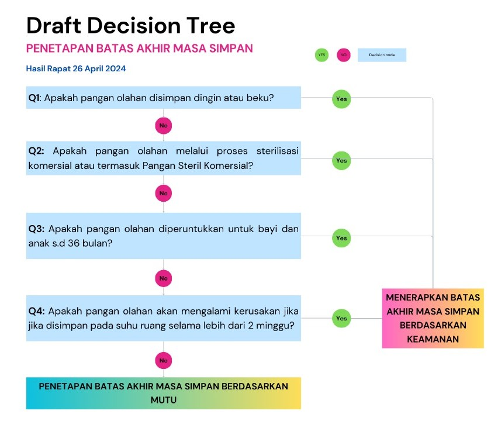

```r
tbl_summ_decision_2
```

```
## # A tibble: 15 × 3
## # Groups:   Kategori Pangan [15]
##    `Kategori Pangan` Keamanan  Mutu
##    <chr>                <dbl> <dbl>
##  1 01                      19    26
##  2 02                       1    27
##  3 03                       2     0
##  4 04                       3     6
##  5 05                       1    22
##  6 06                       2    11
##  7 07                       8    15
##  8 08                       4     4
##  9 09                       7     1
## 10 11                       1     2
## 11 12                       4    37
## 12 13                       7     2
## 13 14                       6    34
## 14 15                       2    14
## 15 16                       6     1
```

```r
reactable(tbl_decision_2, wrap = FALSE, bordered = TRUE, filterable = TRUE,
          columns = list(
            "Kategori Pangan" = colDef(
              sticky = "left",
              width = 100
            ),
            "Jenis Pangan" = colDef(
              sticky = "left",
              width = 250
            )
          )
)
```

| Kategori Pangan | Jenis Pangan | Disimpan dingin atau beku? | Termasuk Pangan Steril Komersial? | Untuk Bayi dan anak sampai 36 Bulan? | Kerusakan pada suhu ruang > 2 minggu? | Keputusan |
| --- | --- | --- | --- | --- | --- | --- |
| 01 | creamer bubuk 25 kg | Tidak | Tidak | Tidak | Tidak | Mutu |
| 01 | dss | Tidak | Tidak | Tidak | Tidak | Mutu |
| 01 | es krim | Ya | Tidak | Tidak | Tidak | Keamanan |
| 01 | es krim | Ya | Tidak | Tidak | Ya | Keamanan |
| 01 | es krim | Ya | Tidak | Tidak | Ya | Keamanan |
| 01 | es krim | Ya | Tidak | Tidak | Ya | Keamanan |
| 01 | es krim | Ya | Tidak | Tidak | Ya | Keamanan |
| 01 | es krim | Ya | Tidak | Tidak | Ya | Keamanan |
| 01 | es stik (ice stick) atau es loli | Ya | Tidak | Tidak | Ya | Keamanan |
| 01 | es susu | Ya | Tidak | Tidak | Ya | Keamanan |

[output cut: 265 more lines]